# IODS course project

### Age

Another variable we looked at was age. We look at the variables in the same way as before

```r
alc %>% group_by(age,high_use) %>% summarise(count = n())
```

```
## # A tibble: 12 x 3
## # Groups:   age [7]
##      age high_use count
##    <int> <lgl>    <int>
##  1    15 FALSE       63
##  2    15 TRUE        18
##  3    16 FALSE       79
##  4    16 TRUE        28
##  5    17 FALSE       64
##  6    17 TRUE        36
##  7    18 FALSE       54
##  8    18 TRUE        27
##  9    19 FALSE        7
## 10    19 TRUE         4
## 11    20 FALSE        1
## 12    22 TRUE         1
```

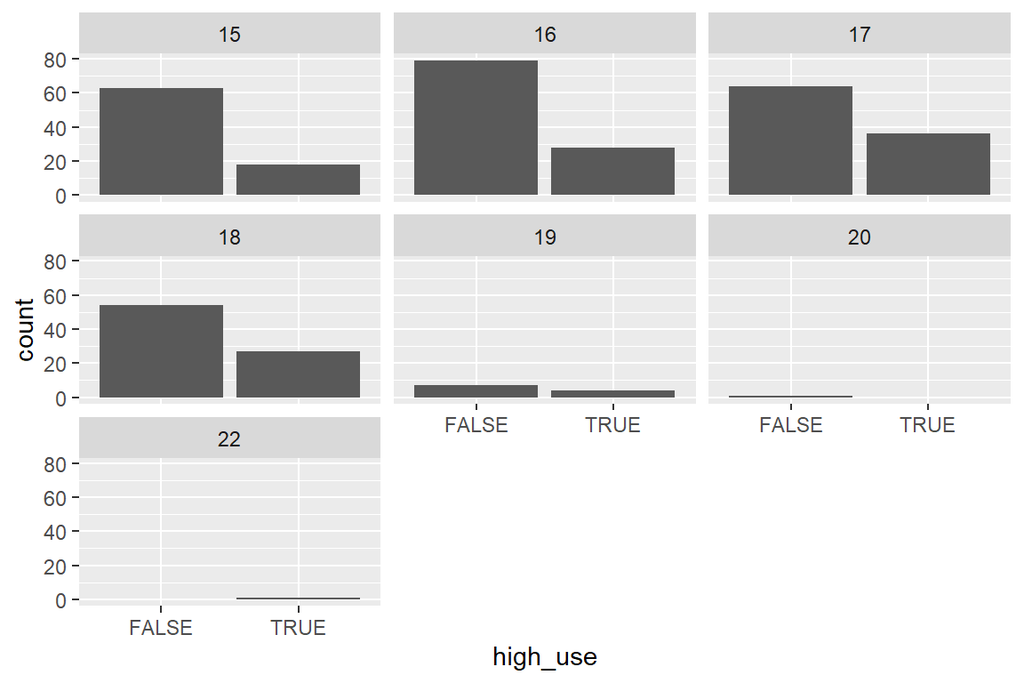

```r
g <- ggplot(data = alc, aes(x=high_use))
g+facet_wrap("age")+geom_bar()
```

Once again, the hypothesis appeared to be true, drinking does increase with age.

### Study hours

The amount of hours spent on studying seems also correlate with drinking.

```r
alc %>% group_by(studytime,high_use) %>% summarise(count = n())
```

```
## # A tibble: 8 x 3
## # Groups:   studytime [4]
##   studytime high_use count
##       <int> <lgl>    <int>
## 1         1 FALSE       58
## 2         1 TRUE        42
## 3         2 FALSE      135
## 4         2 TRUE        60
## 5         3 FALSE       52
## 6         3 TRUE         8
## 7         4 FALSE       23
## 8         4 TRUE         4
```

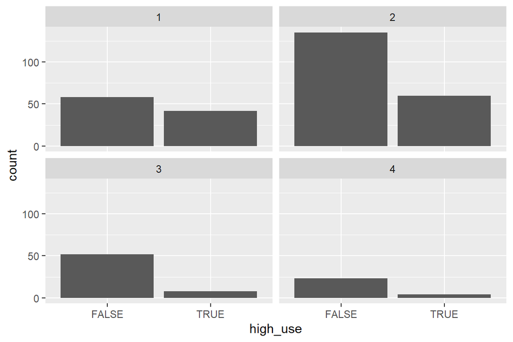

```r
g <- ggplot(data = alc, aes(x=high_use))
g+facet_wrap("studytime")+geom_bar()
```

The percentage of heavy drinkers seems clearly decrease with the amount of hours spent on studying. As study time most likely correlates with academic performance in general, we most likely could have chosen course grades (G1,G2,G3) to get a similar result.

### Parent’s cohabitation status

Last we explored the possibility that whether or not the parent cohabit could have an effect on drinking habits.

```r
alc %>% group_by(Pstatus,high_use) %>% summarise(count = n())
```

```
## # A tibble: 4 x 3
## # Groups:   Pstatus [2]
##   Pstatus high_use count
##   <chr>   <lgl>    <int>
## 1 A       FALSE       26
## 2 A       TRUE        12
## 3 T       FALSE      242
## 4 T       TRUE       102
```

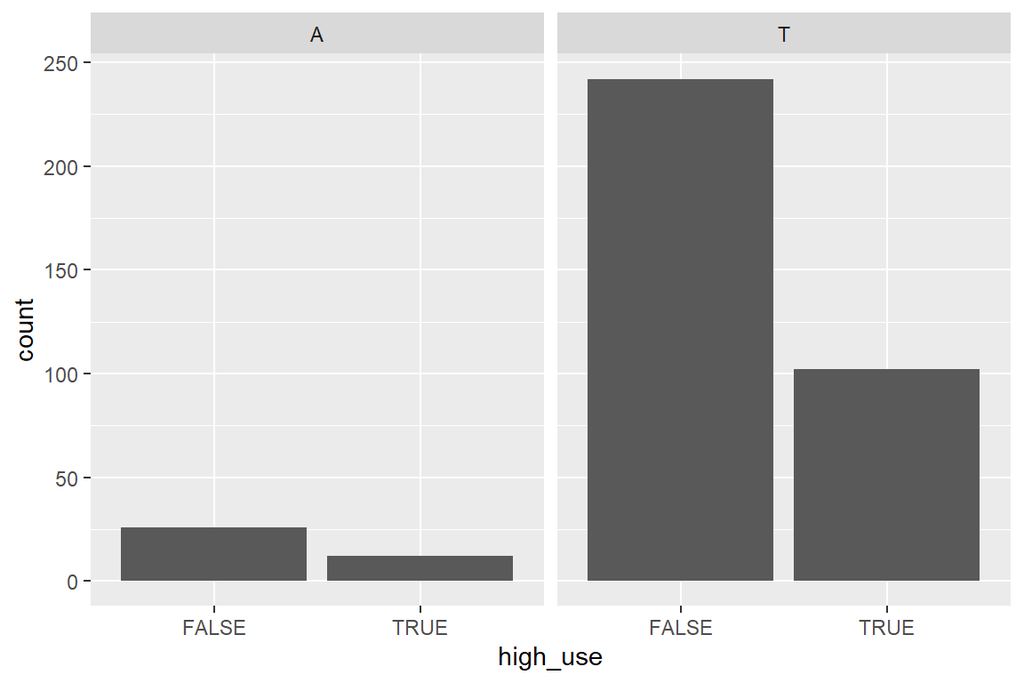

```r
g <- ggplot(data = alc, aes(x=high_use))
g+facet_wrap("Pstatus")+geom_bar()
```

In this case, there seems to be no clear relation between the variables.

## Logistic regression modeling

I included all the considered variables except the parent cohabitation status in the logistic regression model, since it did not seem to affect the amount the students drank.

```r
mdl <- glm(high_use ~ sex + studytime + age, data = alc, family = "binomial")
summary(mdl)
```

```
##
## Call:
## glm(formula = high_use ~ sex + studytime + age, family = "binomial",
##     data = alc)
##
## Deviance Residuals:
##     Min       1Q   Median       3Q      Max
## -1.4737  -0.8178  -0.6672   1.1747   2.2964
##
## Coefficients:
##             Estimate Std. Error z value Pr(>|z|)
## (Intercept)  -3.9603     1.7043  -2.324  0.02014 *
## sexM          0.6687     0.2440   2.741  0.00612 **
## studytime    -0.4851     0.1594  -3.042  0.00235 **
## age           0.2225     0.1001   2.224  0.02615 *
## ---
## Signif. codes:  0 '***' 0.001 '**' 0.01 '*' 0.05 '.' 0.1 ' ' 1
##
## (Dispersion parameter for binomial family taken to be 1)
##
##     Null deviance: 465.68  on 381  degrees of freedom
## Residual deviance: 435.64  on 378  degrees of freedom
## AIC: 443.64
##
## Number of Fisher Scoring iterations: 4
```

The model shows that each of the selected variables have predictive power, as the statistical significance of each model parameter is at least < 0.05. The intercept is quite low, which is follows from the fact that we included age in the regression; since the students are at least 15-16 year old, the positive contribution from age needs to be balanced by a negative intercept. The negative coefficient for study time shows that the amount of studying correlates negatively with the alcohol consumption, whereas being male has an positive effect on the likelihood of excessive drinking (it seems that R has automatically assigned a numerical value 0.0 to females and 1.0 to males in order to perform the regression).

```r
library(DescTools)
OR <- coef(mdl) %>% exp
CI <- MeanCI(OR)
cbind(OR, CI)
```

```
##                     OR         CI
## (Intercept) 0.01905673  0.9589365
## sexM        1.95179032 -0.3632318
## studytime   0.61565757  2.2811048
## age         1.24924140  0.9589365
```

The same interpretation can be made from the odds ratios. Since odds > 1 are positively associated with success, both male sex and age increase the probability of a student drinking much, the opposite is true for studying much OR = 0.62 (< 1.0).

## Testing the predictive power of the model

Last, I tested the models predictive power by calculating the probability of high alcohol use using the original data set, and then comparing the result to the actual value. The results can be summarized in a so-called confusion matrix, which tabulates the predictions versus the ground truth.

```r
probabilities <- predict(mdl, type = "response")
alc <- mutate(alc, probability = probabilities)
alc <- mutate(alc, prediction = probability>0.5)
alc %>% group_by(high_use,prediction) %>% summarise(ratio = n())
```

```
## # A tibble: 4 x 3
## # Groups:   high_use [2]
##   high_use prediction ratio
##   <lgl>    <lgl>      <int>
## 1 FALSE    FALSE        251
## 2 FALSE    TRUE          17
## 3 TRUE     FALSE         95
## 4 TRUE     TRUE          19
```

The values in the summary are the amounts of true and false positives, and true and false negatives. The 0.71 accuracy (accuracy = (TP+TN)/Ntot)) of this model seems to me surprisingly good (considering my low expectations). For a coin toss, the value would be 0.5. On the other hand, the relatively good accuracy is explained by the low number of false positives. The number of false negatives is quite high, so overall this model is not so good in finding out students with a risk of high alcohol consumption.

```r
#load libraries
library(dplyr); library(ggplot2); library(corrplot)
library(MASS); library(tidyr)
```

# Exercise 4

## Reading in and exploring the data

In this weeks exercise we analysed “Boston” dataset from MASS-library. The dataset contains housing values in Boston suburbs in terms of median value of owner-occupied homes, including various other variables, such as crime rate, pollution, etc..

```r
#Let's take a look at the data
data("Boston")
str(Boston)
```

```
## 'data.frame':    506 obs. of  14 variables:
##  $ crim   : num  0.00632 0.02731 0.02729 0.03237 0.06905 ...
##  $ zn     : num  18 0 0 0 0 0 12.5 12.5 12.5 12.5 ...
##  $ indus  : num  2.31 7.07 7.07 2.18 2.18 2.18 7.87 7.87 7.87 7.87 ...
##  $ chas   : int  0 0 0 0 0 0 0 0 0 0 ...
##  $ nox    : num  0.538 0.469 0.469 0.458 0.458 0.458 0.524 0.524 0.524 0.524 ...
##  $ rm     : num  6.58 6.42 7.18 7 7.15 ...
##  $ age    : num  65.2 78.9 61.1 45.8 54.2 58.7 66.6 96.1 100 85.9 ...
##  $ dis    : num  4.09 4.97 4.97 6.06 6.06 ...
##  $ rad    : int  1 2 2 3 3 3 5 5 5 5 ...
##  $ tax    : num  296 242 242 222 222 222 311 311 311 311 ...
##  $ ptratio: num  15.3 17.8 17.8 18.7 18.7 18.7 15.2 15.2 15.2 15.2 ...
##  $ black  : num  397 397 393 395 397 ...
##  $ lstat  : num  4.98 9.14 4.03 2.94 5.33 ...
##  $ medv   : num  24 21.6 34.7 33.4 36.2 28.7 22.9 27.1 16.5 18.9 ...
```

```r
summary(Boston)
```

```
##       crim                zn             indus            chas
##  Min.   : 0.00632   Min.   :  0.00   Min.   : 0.46   Min.   :0.00000
##  1st Qu.: 0.08205   1st Qu.:  0.00   1st Qu.: 5.19   1st Qu.:0.00000
##  Median : 0.25651   Median :  0.00   Median : 9.69   Median :0.00000
##  Mean   : 3.61352   Mean   : 11.36   Mean   :11.14   Mean   :0.06917
##  3rd Qu.: 3.67708   3rd Qu.: 12.50   3rd Qu.:18.10   3rd Qu.:0.00000
##  Max.   :88.97620   Max.   :100.00   Max.   :27.74   Max.   :1.00000
##       nox               rm             age              dis
##  Min.   :0.3850   Min.   :3.561   Min.   :  2.90   Min.   : 1.130
##  1st Qu.:0.4490   1st Qu.:5.886   1st Qu.: 45.02   1st Qu.: 2.100
##  Median :0.5380   Median :6.208   Median : 77.50   Median : 3.207
##  Mean   :0.5547   Mean   :6.285   Mean   : 68.57   Mean   : 3.795
##  3rd Qu.:0.6240   3rd Qu.:6.623   3rd Qu.: 94.08   3rd Qu.: 5.188
##  Max.   :0.8710   Max.   :8.780   Max.   :100.00   Max.   :12.127
##       rad              tax           ptratio          black
##  Min.   : 1.000   Min.   :187.0   Min.   :12.60   Min.   :  0.32
##  1st Qu.: 4.000   1st Qu.:279.0   1st Qu.:17.40   1st Qu.:375.38
##  Median : 5.000   Median :330.0   Median :19.05   Median :391.44
##  Mean   : 9.549   Mean   :408.2   Mean   :18.46   Mean   :356.67
##  3rd Qu.:24.000   3rd Qu.:666.0   3rd Qu.:20.20   3rd Qu.:396.23
##  Max.   :24.000   Max.   :711.0   Max.   :22.00   Max.   :396.90
##      lstat            medv
##  Min.   : 1.73   Min.   : 5.00
##  1st Qu.: 6.95   1st Qu.:17.02
##  Median :11.36   Median :21.20
##  Mean   :12.65   Mean   :22.53
##  3rd Qu.:16.95   3rd Qu.:25.00
##  Max.   :37.97   Max.   :50.00
```

```r
dim(Boston)
```

```
## [1] 506  14
```

Everything seems to be in order. Next I checked the data correlations and distributions.

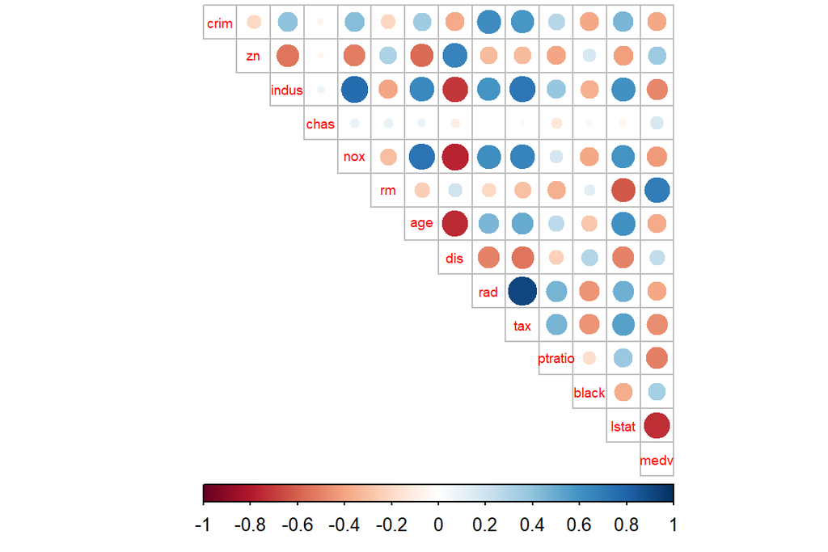

```r
#Let's have a looksie. Since there are quite a few variables, plot each
#plot type separately, instead of using, e.g., pairs.

#Correlations
cor_matrix<-cor(Boston)
corrplot(cor_matrix, method="circle",type='upper',cl.pos = "b", tl.pos = "d" ,tl.cex = 0.6)
```

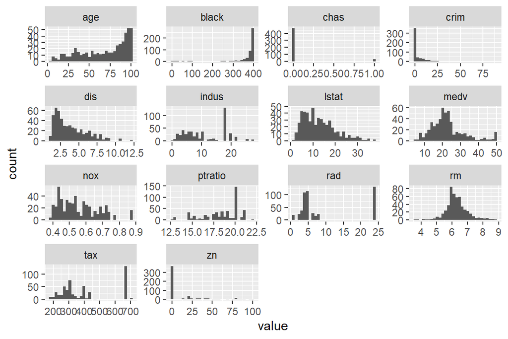

```r
#Histograms
Boston %>%  gather() %>%
  ggplot(aes(value)) +
    facet_wrap(~ key, scales = "free") +
    geom_histogram()
```

There appear to be clear correlations between some of the variables. This is quite expected, since, for instance, industrial areas (indus) are more likely to be more polluted (nox). Also it is not that surprising, that more expensive neighbourhoods have less crime (medv vs crim), and sub urbs with residents of lower socio-economic status (lstat) have higher rates of crime.

Looking at the histograms, it is quite clear that only some of the variables appear to be normally distributed, whereas most are not. This is actually quite worrying, since the fundamental assumption of linear discriminant analysis is that the exploratory variables are normally distributed. Nevertheless, we boldly proceed.

## Scaling and preparing the data

Next, I scaled the data in order to prepare it for the clustering algorithms.

```r
#scale the dataset
boston_scaled <- as.data.frame(scale(Boston))
summary(boston_scaled)
```

```
##       crim                 zn               indus              chas
##  Min.   :-0.419367   Min.   :-0.48724   Min.   :-1.5563   Min.   :-0.2723
##  1st Qu.:-0.410563   1st Qu.:-0.48724   1st Qu.:-0.8668   1st Qu.:-0.2723
##  Median :-0.390280   Median :-0.48724   Median :-0.2109   Median :-0.2723
##  Mean   : 0.000000   Mean   : 0.00000   Mean   : 0.0000   Mean   : 0.0000
##  3rd Qu.: 0.007389   3rd Qu.: 0.04872   3rd Qu.: 1.0150   3rd Qu.:-0.2723
##  Max.   : 9.924110   Max.   : 3.80047   Max.   : 2.4202   Max.   : 3.6648
##       nox                rm               age               dis
##  Min.   :-1.4644   Min.   :-3.8764   Min.   :-2.3331   Min.   :-1.2658
##  1st Qu.:-0.9121   1st Qu.:-0.5681   1st Qu.:-0.8366   1st Qu.:-0.8049
##  Median :-0.1441   Median :-0.1084   Median : 0.3171   Median :-0.2790
##  Mean   : 0.0000   Mean   : 0.0000   Mean   : 0.0000   Mean   : 0.0000
##  3rd Qu.: 0.5981   3rd Qu.: 0.4823   3rd Qu.: 0.9059   3rd Qu.: 0.6617
##  Max.   : 2.7296   Max.   : 3.5515   Max.   : 1.1164   Max.   : 3.9566
##       rad               tax             ptratio            black
##  Min.   :-0.9819   Min.   :-1.3127   Min.   :-2.7047   Min.   :-3.9033
##  1st Qu.:-0.6373   1st Qu.:-0.7668   1st Qu.:-0.4876   1st Qu.: 0.2049
##  Median :-0.5225   Median :-0.4642   Median : 0.2746   Median : 0.3808
##  Mean   : 0.0000   Mean   : 0.0000   Mean   : 0.0000   Mean   : 0.0000
##  3rd Qu.: 1.6596   3rd Qu.: 1.5294   3rd Qu.: 0.8058   3rd Qu.: 0.4332
##  Max.   : 1.6596   Max.   : 1.7964   Max.   : 1.6372   Max.   : 0.4406
##      lstat              medv
##  Min.   :-1.5296   Min.   :-1.9063
##  1st Qu.:-0.7986   1st Qu.:-0.5989
##  Median :-0.1811   Median :-0.1449
##  Mean   : 0.0000   Mean   : 0.0000
##  3rd Qu.: 0.6024   3rd Qu.: 0.2683
##  Max.   : 3.5453   Max.   : 2.9865
```

```r
#Mean vanished, what about the sdev?
apply(boston_scaled,2,sd)
```

```
##    crim      zn   indus    chas     nox      rm     age     dis     rad     tax
##       1       1       1       1       1       1       1       1       1       1
## ptratio   black   lstat    medv
##       1       1       1       1
```

The scale() function does column-wise operations to the data. First it removes the mean from each column and then divides the residuals with their standard deviation.

Next I created a new categorical variable from the crime rate by creating quantiles according to how high or low the crime rate was. For model validation, the data was also split into test and training sets.

```r
bins <- quantile(boston_scaled$crim)
crime <- cut(boston_scaled$crim, breaks = bins, include.lowest = TRUE, label=c("low", "med_low", "med_high", "high"))
# remove original crim from the dataset
boston_scaled <- dplyr::select(boston_scaled, -crim)
# add the new categorical value to scaled data
boston_scaled <- data.frame(boston_scaled, crime)


# number of rows in the Boston dataset
n <- nrow(boston_scaled)
# choose randomly 80% of the rows
ind <- sample(n,  size = n * 0.8)
# create train set
train <- boston_scaled[ind,]
# create test set
test <- boston_scaled[-ind,]
```

## Linear discriminant analysis

Next, I applied linear discriminant analysis (LDA) to the training data. LDA is a statistical method that tries to separate two or more classes of objects by finding a linear combination of features that can be used as an optimal separator.

```r
# linear discriminant analysis
#crime is the target variable, . indicates that all the other are explanatory
#variables
lda.fit <- lda(crime ~ . , data = train)

# print the lda.fit object
lda.fit
```

```
## Call:
## lda(crime ~ ., data = train)
##
## Prior probabilities of groups:
##       low   med_low  med_high      high
## 0.2425743 0.2524752 0.2648515 0.2400990
##
## Group means:
##                   zn      indus        chas        nox          rm        age
## low       0.97452015 -0.9179547 -0.15180559 -0.8557683  0.44991887 -0.8678498
## med_low  -0.07107974 -0.3537110 -0.07933396 -0.6025621 -0.14375814 -0.3909328
## med_high -0.38225131  0.2277269  0.24280554  0.4510580  0.03211119  0.4441293
## high     -0.48724019  1.0149946 -0.02879709  1.0641847 -0.43605064  0.7973202
##                 dis        rad        tax     ptratio       black       lstat
## low       0.8482015 -0.6970982 -0.7243751 -0.45974806  0.38277796 -0.76542127
## med_low   0.4013831 -0.5416255 -0.4942293 -0.06369053  0.31036567 -0.16726306
## med_high -0.4181610 -0.4183710 -0.2986322 -0.34855335  0.09819457  0.05989088
## high     -0.8398618  1.6596029  1.5294129  0.80577843 -0.85998345  0.84842979
##                  medv
## low       0.535977252
## med_low  -0.002607646
## med_high  0.136765646
## high     -0.680382491
##
## Coefficients of linear discriminants:
##                 LD1         LD2         LD3
## zn       0.14939289  0.60597971 -1.02941267
## indus    0.01597595 -0.30890311  0.26426558
## chas     0.01233959 -0.07642989  0.02298134
## nox      0.33232928 -0.79866968 -1.20068548
## rm       0.03403213 -0.02825312 -0.16981114
## age      0.28040691 -0.30855195 -0.08332313
## dis     -0.13780071 -0.26279517  0.27010914
## rad      3.39074673  0.91499115  0.03756064
## tax      0.01231380  0.02090139  0.35900372
## ptratio  0.18774036  0.04856309 -0.25259147
## black   -0.16063374  0.01115023  0.09051118
## lstat    0.14900492 -0.23424114  0.35071541
## medv     0.06378877 -0.44418740 -0.10804593
##
## Proportion of trace:
##    LD1    LD2    LD3
## 0.9514 0.0371 0.0115
```

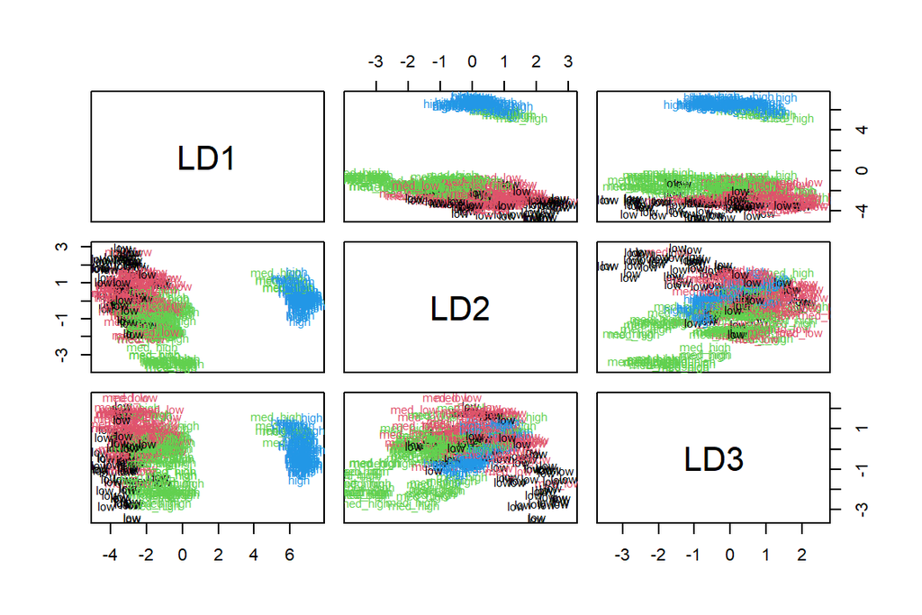

```r
classes <- as.numeric(train$crime)
plot(lda.fit,dimen=3,col = classes,pch = classes)
```

Some clusters clearly emerge. As a next step, I tested the predictive power of the model, using a subset of the original dataset, with the real category included.

```r
# save the correct classes from test data
correct_classes <- test$crime
# remove the crime variable from test data
test <- dplyr::select(test, -crime)
#Make a prediction
lda.pred <- predict(lda.fit, newdata = test)
#and tabulate the results
table(correct = correct_classes, predicted = lda.pred$class)
```

```
##           predicted
## correct    low med_low med_high high
##   low       17      11        1    0
##   med_low    3      13        8    0
##   med_high   1       7       10    1
##   high       0       0        1   29
```

## K-means clustering

To further analyze the data, I applied K-means clustering to the dataset.

```r
#Since the Boston dataset is untouched, it can be used as-is.
#Rewrite the boston_scaled variable
boston_scaled <- as.data.frame(scale(Boston))

#Check out the distance measures
dist_boston <- dist(Boston)
summary(dist_boston)
```

```
##    Min. 1st Qu.  Median    Mean 3rd Qu.    Max.
##   1.119  85.624 170.539 226.315 371.950 626.047
```

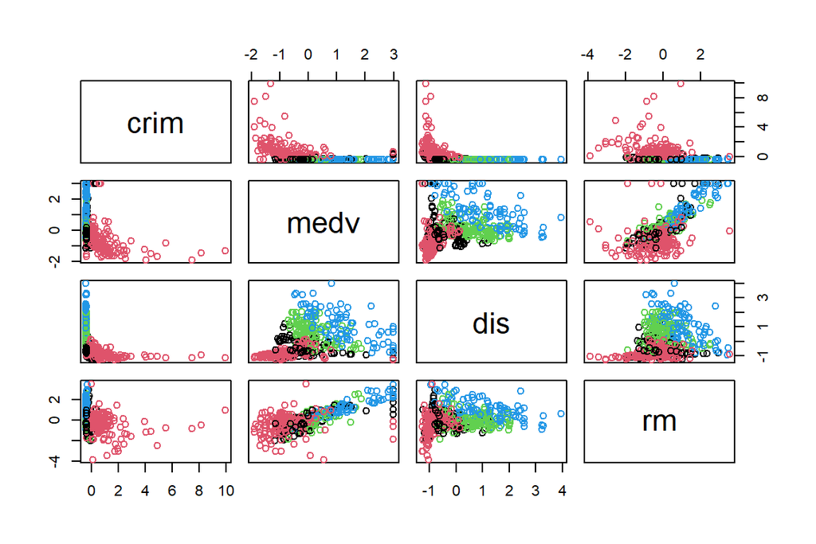

```r
km <-kmeans(boston_scaled, centers = 4)
pairs(boston_scaled[c("crim","medv","dis","rm")], col=km$cluster)
```

An important part of clustering is to actually determine, what is the optimal number of clusters. It can be estimated from the the total cluster sum of squares. The optimum number can be found where the sum changes radically.

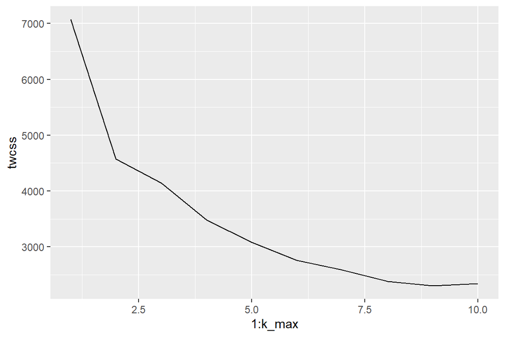

```r
k_max <- 10
# calculate the total within sum of squares
twcss <- sapply(1:k_max, function(k){kmeans(boston_scaled, k)$tot.withinss})

# visualize the results
qplot(x = 1:k_max, y = twcss, geom = 'line')
```

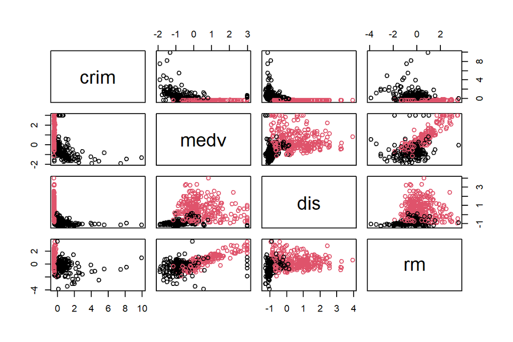

```r
km <-kmeans(boston_scaled, centers = 2)
pairs(boston_scaled[c("crim","medv","dis","rm")], col=km$cluster)
```

In this case, the optimum number of clusters appeared to be 2. Two clusters clearly separate the dataset to areas, where the crime is virtually non-existent, and to areas, where there is crime.

## Using K-means clusters to classify the data for linear discriminant analysis

```r
#Since the Boston dataset is untouched, it can be used as-is.
#Rewrite the boston_scaled variable
boston_scaled <- as.data.frame(scale(Boston))

#Use four clusters this time
km <-kmeans(boston_scaled, centers = 4)
clusters = km$cluster
lda.fit <- lda(crim ~ . , data = boston_scaled)
```

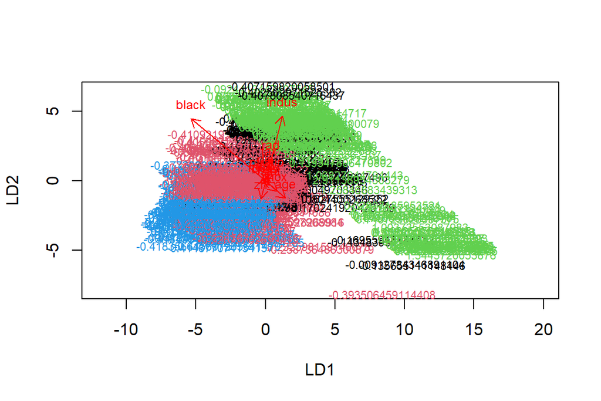

```
## integer(0)
```

```r
lda.arrows <- function(x, myscale = 1, arrow_heads = 0.1, color = "red", tex = 0.75, choices = c(1,2)){
  heads <- coef(x)

  arrows(x0 = 0, y0 = 0,
         x1 = myscale * heads[,choices[1]],
         y1 = myscale * heads[,choices[2]], col=color, length = arrow_heads)
  text(myscale * heads[,choices], labels = row.names(heads),
       cex = tex, col=color, pos=3)
}


#plot(lda.fit,dimen=2,col = clusters,pch = clusters)
plot(lda.fit,dimen=2,col = clusters,pch = clusters)+lda.arrows(lda.fit,myscale=2.0)
```

It seems the sub-urban areas are divided quite strongly into industrial areas (indu) and areas predominately populated by black people (black=(1000(Bk - 0.63)^2 where Bk is the proportion of blacks by town. ), as these seem to be the strongest linear separators.

## Data wrangling for the next week.

This is done by a script create_human.R

# Exercise 5 - Dimensionality reduction

In this exercise we used data that was wrangled together from human development and gender inequality data by country. We have variables:

- “country”
- “edu2F” (Proportion of females with at least secondary education)
- “labourF” (Proportion of females in the labour force)
- “exp.edu” (Expected years of schooling, both sexes)
- “life.exp” (average life expectancy)
- “GNI” (Gross National Income per capita)
- “mat.mort”(Maternal mortality ratio)
- “ado.birth” (Adolescent birth rate)
- “parl.rep” (Percetange of female representatives in parliament)

## Reading in and checking the data

```r
#load libraries
library(dplyr); library(GGally)

human <- read.table("./data/human.txt",header=TRUE)
# First, check that the data is OK. Should be 155 obs and 8 variables
dim(human)
```

```
## [1] 155   8
```

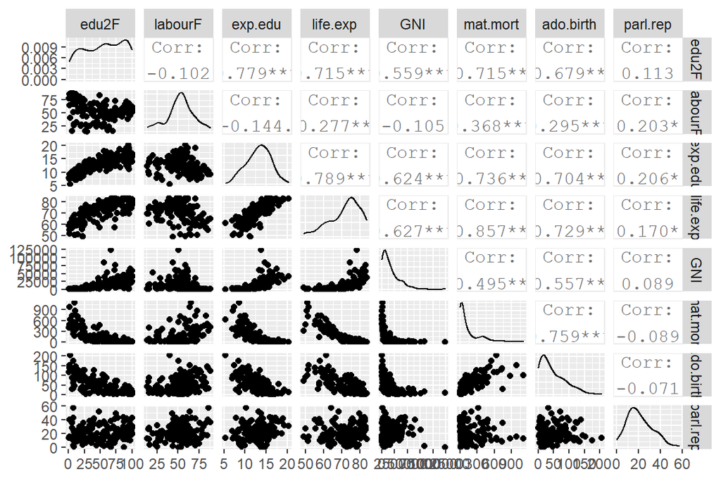

```r
ggpairs(human)
```

Many of the distributions seem to be normal, or at least they are a blend of normal distribution and something else. Some of the more skewed distributions appear also to be normal, but they are only capped at the left hand side (GNI, maternal mortality, for instance). There are quite a few strong correlations (education increases life expectancy). GNI has a tendency to correlate with just about everything, but there is a weird phenomenon, that for some variables, the correlation appears to be more like a condition than an explanation (for the lack of a better word). For example, maternal mortality can be high only if GNI is low, but a low GNI does not predict explicitly, what the maternal mortality will be.

## Principal component analysis

After checking that the data set was OK, I applied principal component analysis to the data:

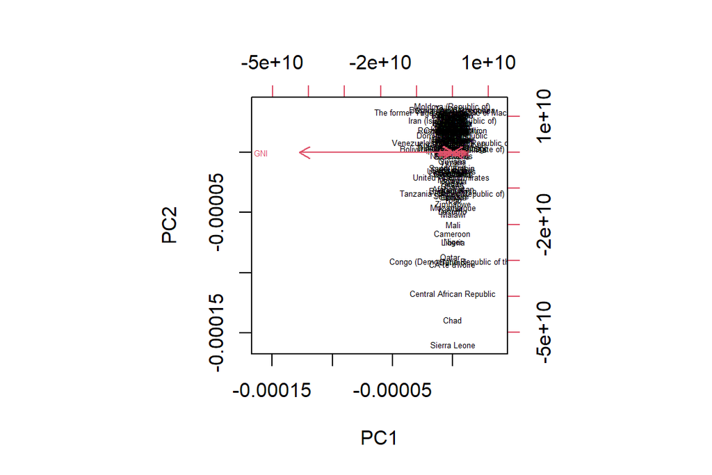

```r
pca_human <- prcomp(human)
biplot(pca_human, choices = 1:2,cex=0.4,scale=2.0)
```

OK, that looked a bit messy, and GNI dominates the first principal component too much. The second principal component seems to deal with variables that contain a certain dichotomy between developed and non-developed countries. Standardizing the variables might help:

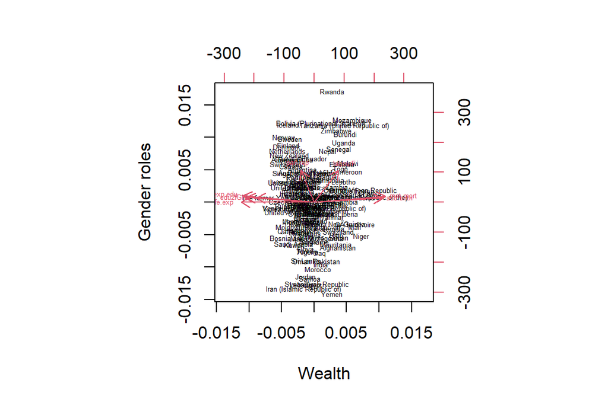

```r
human_std <- scale(human)
pca_human <- prcomp(human_std)
biplot(pca_human, choices = 1:2,cex=0.4,scale=2.0,xlab="Wealth", ylab="Gender roles")
```

Scaling seemed to help somewhat, but the plot is still quite terrible (sorry!). With some zooming and scaling following interpretations can be made:

- Principal component 1 could be described as something like an industrialization, or wealth index. In the countries on the left-hand side have women have more education, the child mortality is low etc.. On the right-hand side, countries are poorer, the child mortality is higher and there are more adolescents giving birth to children.
- The second principal component shows how much women participate in the society in general, both in governmental roles and also int the general workforce.
- Western and some African countries have a high percentage of females in active roles in the society
- Middle-eastern (or maybe islamic?) countries, even if they might be moderately wealthy, are much more male dominated than the other countries.

## Factominer data

As a last part of this exercise, we examine the “tea” dataset from FactoMineR library. Since the number of variables is huge, I selected just a few for the analysis. Also, the bar plot worked only in the individually knitted chapter, so it was left away from the fully knitted document.

```r
library(FactoMineR)
library(tidyr)
library(devtools)
reload(inst("dplyr"))
data(tea)
str(tea)
```

```
## 'data.frame':    300 obs. of  36 variables:
##  $ breakfast       : Factor w/ 2 levels "breakfast","Not.breakfast": 1 1 2 2 1 2 1 2 1 1 ...
##  $ tea.time        : Factor w/ 2 levels "Not.tea time",..: 1 1 2 1 1 1 2 2 2 1 ...
##  $ evening         : Factor w/ 2 levels "evening","Not.evening": 2 2 1 2 1 2 2 1 2 1 ...
##  $ lunch           : Factor w/ 2 levels "lunch","Not.lunch": 2 2 2 2 2 2 2 2 2 2 ...
##  $ dinner          : Factor w/ 2 levels "dinner","Not.dinner": 2 2 1 1 2 1 2 2 2 2 ...
##  $ always          : Factor w/ 2 levels "always","Not.always": 2 2 2 2 1 2 2 2 2 2 ...
##  $ home            : Factor w/ 2 levels "home","Not.home": 1 1 1 1 1 1 1 1 1 1 ...
##  $ work            : Factor w/ 2 levels "Not.work","work": 1 1 2 1 1 1 1 1 1 1 ...
##  $ tearoom         : Factor w/ 2 levels "Not.tearoom",..: 1 1 1 1 1 1 1 1 1 2 ...
##  $ friends         : Factor w/ 2 levels "friends","Not.friends": 2 2 1 2 2 2 1 2 2 2 ...
##  $ resto           : Factor w/ 2 levels "Not.resto","resto": 1 1 2 1 1 1 1 1 1 1 ...
##  $ pub             : Factor w/ 2 levels "Not.pub","pub": 1 1 1 1 1 1 1 1 1 1 ...
##  $ Tea             : Factor w/ 3 levels "black","Earl Grey",..: 1 1 2 2 2 2 2 1 2 1 ...
##  $ How             : Factor w/ 4 levels "alone","lemon",..: 1 3 1 1 1 1 1 3 3 1 ...
```

[output cut: 22 more lines]

```r
dim(tea)
```

```
## [1] 300  36
```

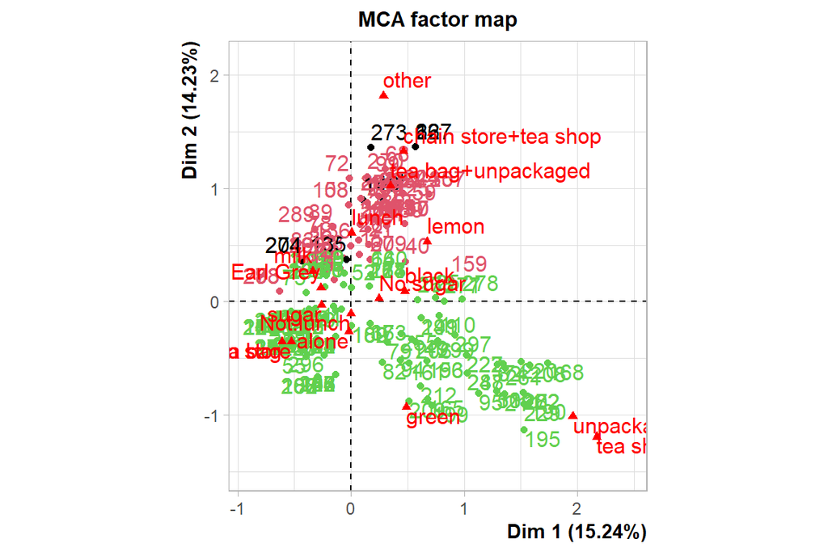

```r
keep_columns <- c("Tea", "how", "How", "sugar", "where", "lunch")
# select the 'keep_columns' to create a new dataset
tea_time <- select(tea, keep_columns)
#gather(tea_time)  %>% ggplot(aes(value)) + facet_wrap("key", scales = "free")

# look at the summaries and structure of the data

mca <- MCA(tea_time, graph = FALSE)
km_data=data.frame(mca$ind$coord)
km <-kmeans(km_data, centers = 3)

plot(mca,col.ind=km$cluster)
```

From the MCA factor map we find that Dimension 1 divides the tea drinkers into those who use milk (and usually drink Earl Gray), and those who drink their tea black. The other dimension seems to measure “greenness”, and whether or not the tea is brewed with tea bags or not. I also coloured the plot with results from a K-means clustering with three clusters. From this, I would identify three groups, sophisticated green tea drinkers (green), sophisticated black tea drinkers (reddish), and casual tea drinkers (black).

# Exercise 6 - Analysis of longitudinal data

## Data wrangling

First, run the data wrangling script created earlier

```r
RATSL <- read.table("./data/RATSL.txt")
BPRSL <- read.table("./data/BPRSL.txt")

#Data must be "re-factored" :P
BPRSL$treatment <- factor(BPRSL$treatment)
BPRSL$subject <- factor(BPRSL$subject)

RATSL$Group <- factor(RATSL$Group)
RATSL$ID <- factor(RATSL$ID)
```

The data was transformed during wrangling from wide to long form. What this means, is that it groups together and turns several variables (for example, week1,week2, etc.,) into one variable (week), that has multiple values (1,2,3, etc.). Basically, the process creates a *time series* from those variables (this is just because the dimension of the variable is time in this case).

## Rat data

The first data set is from a rat nutrition study. The three groups were put on different diets, and each animal’s body weight (grams) was recorded repeatedly (approximately weekly, except in week seven when two recordings were taken) over a 9-week period.

First, I plotted the data without any scaling

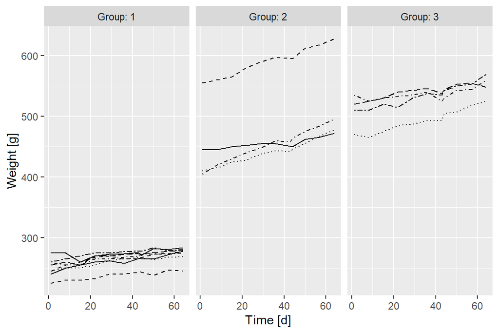

```r
library(ggplot2)
ggplot(RATSL, aes(x = RATSL$time, y = RATSL$weight, linetype = ID)) +  geom_line() +  scale_linetype_manual(values = rep(1:10, times=4)) +  facet_grid(. ~ Group, labeller = label_both) +  theme(legend.position = "none") + scale_x_continuous(name="Time [d]")  + scale_y_continuous(name="Weight [g]",limits = c(min(RATSL$weight), max(RATSL$weight)))
```

Next, I checked how scaling affects the data. I took the average of the weight of every rats at each time point in order to see, what kind of systematic trend is there (or not). Error bars are given by the average error of the mean.

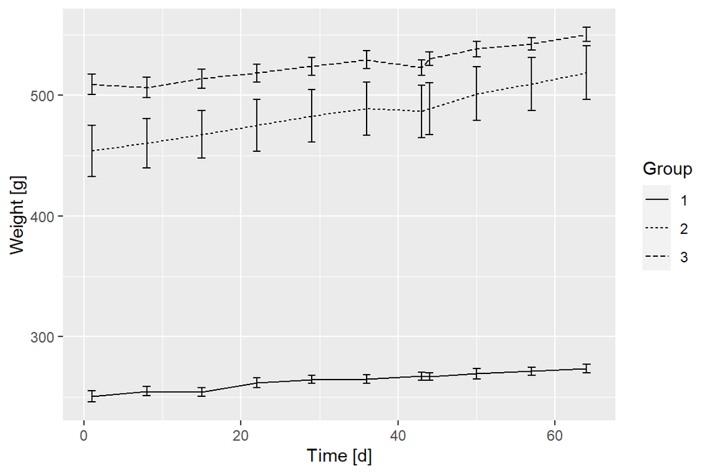

```r
n <- RATSL$time %>% unique() %>% length()
n=11
RATSL_scaled <- RATSL %>% group_by(Group, time) %>% summarise( mean = mean(weight), se = sd(weight )/sqrt(n)) %>% ungroup()

ggplot(RATSL_scaled, aes(x = time, y = mean, linetype=Group, shape = Group)) +
    geom_line() +
    geom_errorbar(aes(ymin=mean-se, ymax=mean+se, linetype="1"), width=1)+ scale_y_continuous(name="Weight [g]")+scale_x_continuous(name="Time [d]")
```

## Summary measure analysis

We check the effect of the diet by comparing mean of the differences of the first and the last weight measurement, i.e., it is the summary measure.

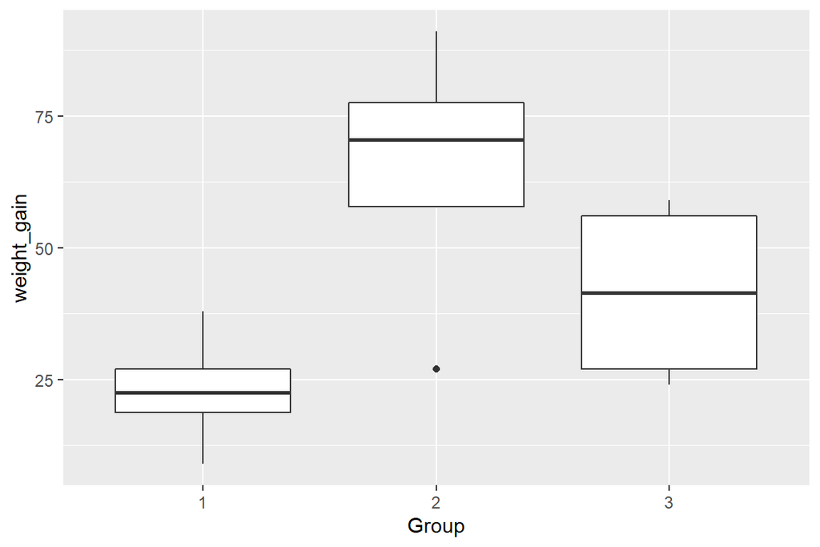

```r
#get the first and last weights

first_weight <-RATSL %>% filter(time==min(time)) %>% select(weight, Group, ID)
last_weight <- RATSL %>% filter(time==max(time)) %>% select(weight, Group, ID)
RATSL_summary <- select(first_weight,Group,ID)
RATSL_summary$first_weight <- first_weight$weight #this was done afterwards :)
RATSL_summary$weight_gain <- last_weight$weight-first_weight$weight


# Draw a boxplot of the mean versus treatment
ggplot(RATSL_summary, aes(x = Group, y = weight_gain)) +
  geom_boxplot() +
  stat_summary(fun.y = "difference", geom = "point", shape=23, size=4, fill = "white")
```

There appears to be one outlier in group 2, so that will be removed

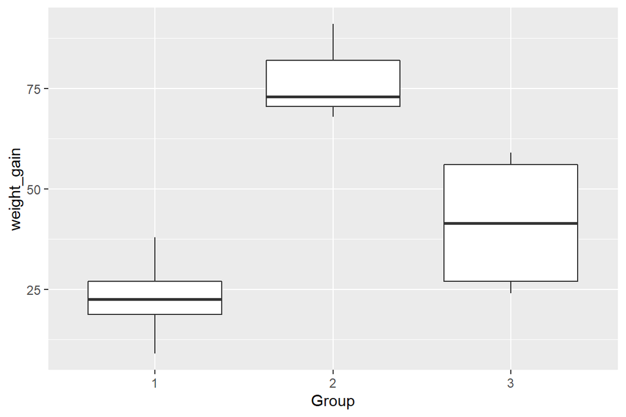

```r
RATSL_fout <- filter(RATSL_summary, !(weight_gain<30 & Group ==2))


# Draw a boxplot of the mean versus treatment
ggplot(RATSL_fout, aes(x = Group, y = weight_gain)) +
  geom_boxplot() +
  stat_summary(fun.y = "difference", geom = "point", shape=23, size=4, fill = "white")
```

There are clearly differences between the groups, and the removal of the outlier clearly accentuated those differences.

## T-test and Anova

```r
fit <- lm(weight_gain ~ Group + first_weight, data= RATSL_fout)
anova(fit)
```

```
## Analysis of Variance Table
##
## Response: weight_gain
##              Df Sum Sq Mean Sq F value    Pr(>F)
## Group         2 6449.2  3224.6 22.6547 0.0001257 ***
## first_weight  1  306.8   306.8  2.1557 0.1700452
## Residuals    11 1565.7   142.3
## ---
## Signif. codes:  0 '***' 0.001 '**' 0.01 '*' 0.05 '.' 0.1 ' ' 1
```

## BPRS data

This data set is taken from Davis (2002). Here 40 male subjects were randomly assigned to one of two treatment groups and each subject was rated on the brief psychiatric rating scale (BPRS) measured before treatment began (week 0) and then at weekly intervals for eight weeks. The BPRS assesses the level of 18 symptom constructs such as hostility, suspiciousness, hallucinations and grandiosity; each of these is rated from one (not present) to seven (extremely severe). The scale is used to evaluate patients suspected of having schizophrenia.

Here is the plot of the treatment progress

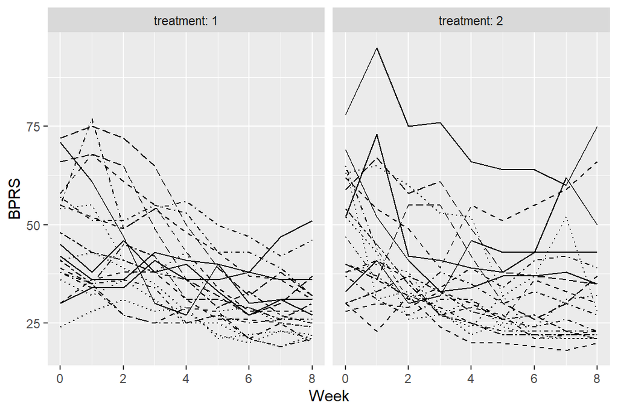

```r
ggplot(BPRSL, aes(x = BPRSL$week, y = BPRSL$bprs, linetype = subject)) +  geom_line() +  scale_linetype_manual(values = rep(1:10, times=4)) +  facet_grid(. ~ treatment, labeller = label_both) +  theme(legend.position = "none") + scale_x_continuous(name="Week")  + scale_y_continuous(name="BPRS")
```

## Linear model

First I fitted a linear model to the data

```r
#bprs is the target, week and treatment explanatory variables
model <- lm(bprs ~ week + treatment, data=BPRSL)
summary(model)
```

```
##
## Call:
## lm(formula = bprs ~ week + treatment, data = BPRSL)
##
## Residuals:
##     Min      1Q  Median      3Q     Max
## -22.454  -8.965  -3.196   7.002  50.244
##
## Coefficients:
##             Estimate Std. Error t value Pr(>|t|)
## (Intercept)  46.4539     1.3670  33.982   <2e-16 ***
## week         -2.2704     0.2524  -8.995   <2e-16 ***
## treatment2    0.5722     1.3034   0.439    0.661
## ---
## Signif. codes:  0 '***' 0.001 '**' 0.01 '*' 0.05 '.' 0.1 ' ' 1
##
## Residual standard error: 12.37 on 357 degrees of freedom
## Multiple R-squared:  0.1851, Adjusted R-squared:  0.1806
## F-statistic: 40.55 on 2 and 357 DF,  p-value: < 2.2e-16
```

The model clearly shows, that the treatment group has no significant effect on the outcome, but the bprs score decreases very strongly with time.

## Random intercept model

Since the previous model assumes that the results of the measurements are independent of each other, and with repeated measurements of the same subjects, this is clearly not true. A better choice is the random intercept model

```r
library(lme4)

ri_model <- lmer(bprs ~ week + treatment + (1 | subject), data=BPRSL, REML = FALSE)
summary(ri_model)
```

```
## Linear mixed model fit by maximum likelihood  ['lmerMod']
## Formula: bprs ~ week + treatment + (1 | subject)
##    Data: BPRSL
##
##      AIC      BIC   logLik deviance df.resid
##   2748.7   2768.1  -1369.4   2738.7      355
##
## Scaled residuals:
##     Min      1Q  Median      3Q     Max
## -3.0481 -0.6749 -0.1361  0.4813  3.4855
##
## Random effects:
##  Groups   Name        Variance Std.Dev.
##  subject  (Intercept)  47.41    6.885
##  Residual             104.21   10.208
## Number of obs: 360, groups:  subject, 20
##
## Fixed effects:
##             Estimate Std. Error t value
## (Intercept)  46.4539     1.9090  24.334
## week         -2.2704     0.2084 -10.896
## treatment2    0.5722     1.0761   0.532
##
## Correlation of Fixed Effects:
##            (Intr) week
## week       -0.437
## treatment2 -0.282  0.000
```

## Random intercept and random slope model

```r
library(lme4)

rirs_model <- lmer(bprs ~ week + treatment + (week | subject), data=BPRSL, REML = FALSE)
summary(rirs_model)
```

```
## Linear mixed model fit by maximum likelihood  ['lmerMod']
## Formula: bprs ~ week + treatment + (week | subject)
##    Data: BPRSL
##
##      AIC      BIC   logLik deviance df.resid
##   2745.4   2772.6  -1365.7   2731.4      353
##
## Scaled residuals:
##     Min      1Q  Median      3Q     Max
## -2.8919 -0.6194 -0.0691  0.5531  3.7976
##
## Random effects:
##  Groups   Name        Variance Std.Dev. Corr
##  subject  (Intercept) 64.8222  8.0512
##           week         0.9609  0.9802   -0.51
##  Residual             97.4305  9.8707
## Number of obs: 360, groups:  subject, 20
##
## Fixed effects:
##             Estimate Std. Error t value
## (Intercept)  46.4539     2.1052  22.066
## week         -2.2704     0.2977  -7.626
## treatment2    0.5722     1.0405   0.550
##
## Correlation of Fixed Effects:
##            (Intr) week
## week       -0.582
## treatment2 -0.247  0.000
```

According to the loglikelihood, this model is marginally better fit than the previous one.

## Random intercept and random slope model with interaction

Finally, we allow interaction between the time and treatment

```r
rirswi_model <- lmer(bprs ~ week + treatment + week*treatment + (week | subject), data=BPRSL, REML = FALSE)
summary(rirswi_model)
```

```
## Linear mixed model fit by maximum likelihood  ['lmerMod']
## Formula: bprs ~ week + treatment + week * treatment + (week | subject)
##    Data: BPRSL
##
##      AIC      BIC   logLik deviance df.resid
##   2744.3   2775.4  -1364.1   2728.3      352
##
## Scaled residuals:
##     Min      1Q  Median      3Q     Max
## -3.0512 -0.6271 -0.0768  0.5288  3.9260
##
## Random effects:
##  Groups   Name        Variance Std.Dev. Corr
##  subject  (Intercept) 64.9964  8.0620
##           week         0.9687  0.9842   -0.51
##  Residual             96.4707  9.8220
## Number of obs: 360, groups:  subject, 20
##
## Fixed effects:
##                 Estimate Std. Error t value
## (Intercept)      47.8856     2.2521  21.262
## week             -2.6283     0.3589  -7.323
## treatment2       -2.2911     1.9090  -1.200
## week:treatment2   0.7158     0.4010   1.785
##
## Correlation of Fixed Effects:
##             (Intr) week   trtmn2
## week        -0.650
## treatment2  -0.424  0.469
## wek:trtmnt2  0.356 -0.559 -0.840
```

The plots are admittedly a bit clumsy, for some reason, there is a linestyle related error if I don’t divide the plots according to the treatment type.

```r
anova(rirswi_model,rirs_model)
```

```
## Data: BPRSL
## Models:
## rirs_model: bprs ~ week + treatment + (week | subject)
## rirswi_model: bprs ~ week + treatment + week * treatment + (week | subject)
##              npar    AIC    BIC  logLik deviance  Chisq Df Pr(>Chisq)
## rirs_model      7 2745.4 2772.6 -1365.7   2731.4
## rirswi_model    8 2744.3 2775.4 -1364.1   2728.3 3.1712  1    0.07495 .
## ---
## Signif. codes:  0 '***' 0.001 '**' 0.01 '*' 0.05 '.' 0.1 ' ' 1
```

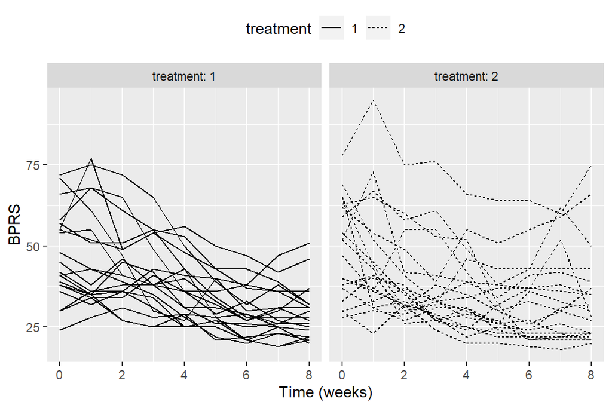

```r
ggplot(BPRSL, aes(x = week, y = bprs, group = subject)) +
  facet_grid(. ~ treatment, labeller = label_both)+
  geom_line(aes(linetype = treatment)) +
  scale_x_continuous(name = "Time (weeks)")+
  scale_y_continuous(name = "BPRS") +
  theme(legend.position = "top")
```

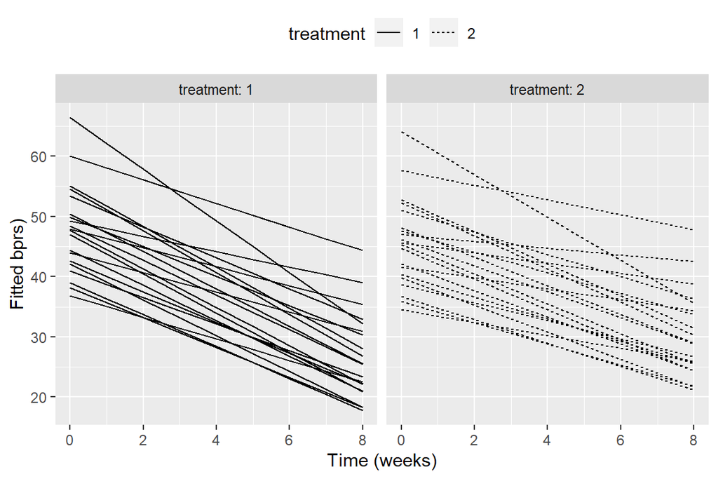

```r
fitted_vector = fitted(rirswi_model)

ggplot(BPRSL, aes(x = week, y = fitted_vector, group = subject)) +
  facet_grid(. ~ treatment, labeller = label_both)+
  geom_line(aes(linetype = treatment)) +
  scale_x_continuous(name = "Time (weeks)") +
  scale_y_continuous(name = "Fitted bprs)") +
  theme(legend.position = "top")
```